# WellbeingAnalytics

Uli Kaulfuß

2 November 2019

# Wellbeing Analytics

### Preparing

```r
suppressWarnings({
  DE_data <- read.dta13("data/GEDA14.dta")
  EN_data <- read.dta13("data/translated.data.set.dta")

  DE_data$RowID <- seq.int(nrow(DE_data))
  EN_data$RowID <- seq.int(nrow(EN_data))

  save(EN_data, file = "data/translated.data.set.RData")
})

head(EN_data)
```

```
##      sex  sexb          age5B         age10B  agegrp1  agegrp2  agegrp4
## 1 Female women 30 to 34 years 30 to 39 years 18-39 J. 18-64 J. 30-39 J.
## 2 Female women 50 to 54 years 50 to 59 years 40-59 J. 18-64 J. 50-59 J.
## 3 Female women 50 to 54 years 50 to 59 years 40-59 J. 18-64 J. 50-59 J.
## 4 Female women 40 to 44 years 40 to 49 years 40-59 J. 18-64 J. 40-49 J.
## 5 Female women 20 to 24 years 20 to 29 years 18-39 J. 18-64 J. 18-29 J.
## 6 Female women 45 to 49 years 40 to 49 years 40-59 J. 18-64 J. 40-49 J.
##    agegrp6  agegrp7  agegrp8  agegrp9 agegrp10 agegrp11 agegrp12 untm untj
## 1 30-39 J. 30-39 J. 30-44 J. 25-39 J. 25-34 J. 25-39 J. 30-44 J.    5 2015
## 2 50-59 J. 50-59 J. 45-64 J. 40-54 J. 45-54 J. 50-59 J. 45-64 J.    1 2015
## 3 50-59 J. 50-59 J. 45-64 J. 40-54 J. 45-54 J. 50-59 J. 45-64 J.   12 2014
## 4 40-49 J. 40-49 J. 30-44 J. 40-54 J. 35-44 J. 40-49 J. 30-44 J.   12 2014
## 5 18-29 J. 18-24 J. 18-29 J. 18-24 J. 18-24 J. 18-24 J. 18-29 J.    5 2015
## 6 40-49 J. 40-49 J. 45-64 J. 40-54 J. 45-54 J. 40-49 J. 45-64 J.    4 2015
##    ppoint                          ktyp4                          bula
```

[output cut: 503 more lines]

```r
df_base <- DE_data %>% dplyr::select(
 KHhyp12, # Bluthochdruck: I.d.l.12 Mon.
KHhyp, # Bluthochdruck: Jemals ärztlich diagnostiziert
KHhyp12pB, # Indikator bek. (ärztl. diagn.) Bluthochdruckdruck i.d.l. 12 Mon
KHhypmedC, # Indikator blutdrucksenkende Mittel bei bekannter Hypertonie
KHmyo12, # Herzinfarkt: I.d.l. 12 Mon.
KHkhk12, # Koronare Herzerkrankung/Angina Pectoris: I.d.l.12 Mon.
KHbbmyo12,# Herzinfarkt/chron. Beschw.: I.d.l. 12 Mon.
KHhi12, # Herzinsuffizienz: I.d.l.12 Mon.
KHsa12, # Schlaganfall: I.d.l.12 Mon.
KHbbsa12, # Schlaganfall/ chron. Beschwerden infolge SA: I.d.l.12 Mon.
KHdiabB12, # Diabetes: I.d.l.12 Mon.
KHab12, # Asthma: I.d.l.12 Mon.
KHkarz12, # Krebserkrankung: I.d.l.12 Mon.
KHlip12A, # Erhöhte Blutfette/Chol.: I.d.l.12 Mon.
KHlipA, # Jemals erhöhte Blutfette/Cholesterinw. (Arztdiagnose)
KHlipmedA, # Erhöhtes Cholesterin: Zurzeit Medikamenteneinnahme
KHcb12,# Chronische Bronchitis: I.d.l.12 Mon.
KHulc12,# Magen- oder Zwölffingerdarmgeschwür: I.d.l.12 Mon.
KHced12,# Chronisch entzündliche Darmerkrankung: I.d.l.12 Mon.
KHlz12,# Leberzirrhose: I.d.l.12 Mon.
KHcle12,# Andere chronische Lebererkrankungen: I.d.l.12 Mon.
KHniB12,# Chron. Nierenprobleme: I.d.l.12 Mon.
KHdge12,# Arthrose: I.d.l.12 Mon.
KHra12,# Arthritis: I.d.l.12 Mon.
KHos12,# Osteoporose: I.d.l.12 Mon.
KHalgi112,# Allergien: I.d.l. 12 Mon.
GZmehm1,# Allg. Gesundheitszustand
GZmehm3C,# Chronische Krankheiten
GZmehm2D,# Einschränkung durch Krankheit seit mind. 6 Monaten
GZsubj1,# Achten auf Gesundheit
SHseh1,# Brille oder Kontaktlinsen
SHhoer1,# Hörgerät
BBmyo12,# Chronische Beschwerden nach Herzinfarkt: I.d.l.12 Mon.
BBsa12,# Chronische Beschw. infolge eines Schlaganfalls: I.d.l.12 Mon.
BBdors112,# Beschwerden unterer Rücken: I.d.l.12 Mon.
BBdors212,# Beschwerden Nacken, Halswirbelsäule: I.d.l.12 Mon.
BBblas12B,# Harninkontinenz: I.d.l.12 Mon.
BBschwierig1,# Schwierigk. bei Ausführen o. Hilfe: Essen oder Trinken
BBschwierig2,# Schwierigk. bei Ausführen o. Hilfe: v. Bett/Stuhl erheben od. niederlassen
BBschwierig3,# Schwierigk. bei Ausführen o. Hilfe: An- und Ausziehen
BBschwierig4,# Schwierigk. bei Ausführen o. Hilfe: Toilettenbenutzung
BBschwierig5,# Schwierigk. bei Ausführen o. Hilfe: Baden oder Duschen
BBhh1,# Schwierigk. Ausführen o. Hilfe: Mahlzeiten zubereiten
BBhh2,# Schwierigk. Ausführen o. Hilfe: Das Telefon benutzen
BBhh3,# Schwierigk. Ausführen o. Hilfe: Einkäufe erledigen
BBhh4,# Schwierigk. Ausführen o. Hilfe: Medikamenteneinn. org.
BBhh5,# Schwierigk. Ausführen o. Hilfe: Leichte Hausarbeit erledig.
BBhh6,# Schwierigk. Ausführen o. Hilfe: Gelegentlich schwere Hausarbeit erled.
BBhh7,# Schwierigk. Ausführen o. Hilfe: Org. fin. und alltägl. Verwaltungsangeleg.
BBbehB,# Amtlich anerkannte Behinderung
UVartverkehr,# Verletzung wg. Unfall i.d.l. 12 Monaten: Verkehrsunfall
UVarthaus,# Verletzung wg. Unfall i.d.l. 12 Monaten: Unfall zu Hause
UVartfreiz,# Verletzung wg. Unfall i.d.l. 12 Monaten: Unfall in der Freizeit
UVarbeit1,# Verletzung Arbeitsunfall: I.d.l. 12 Mon. (kein Wegeunfall)
SEschwA_zz,# Schwanger zur Zeit
LQsf367C,# Stärke Schmerzen i.d.l. 4 Wochen
LQsf368C,# Behinderung in Alltagstätigkeiten durch Schmerzen i.d.l. 4 Wochen
LQzufrB10,# Zufriedenheit: Leben insgesamt
PKdep12,# Depression: I.d.l. 12 Mon.
PKphq1,# Beeintr. i.d.l. 2 Wo.: Wenig Interesse/Freude an Ihren Tätigkeiten
PKphq2,# Beeintr. i.d.l. 2 Wo.: Niedergeschlagenheit, Schwermut/Hoffnungslosigkeit
PKphq3,# Beeintr. i.d.l. 2 Wo.: Schwierigk., ein-/durchzuschlafen od. vermehrter Schlaf
PKphq4,# Beeintr. i.d.l. 2 Wo.: Müdigkeit/Gefühl, k. Energie zu haben
PKphq5,# Beeintr. i.d.l. 2 Wo.: Vermind. Appetit/übermäßiges Bedürfnis zu essen
PKphq6,# Beeintr. i.d.l. 2 Wo.: Schlechte Meinung v. sich; Versagen/Familie zu entt.
PKphq7,# Beeintr. i.d.l. 2 Wo.: Schwierigk., sich zu konzentrieren
PKphq8,# Beeintr. i.d.l. 2 Wo.: Veränderung in Bewegung oder Sprache
SFoslo1C,# Nahestehende Personen
SFoslo2C,# Anteilnahme anderer Personen
SFoslo3A,# Erhalt von Hilfe
SFosloA,# Soziale Unterstützung (Oslo-3 Social Support Scale)
IAhypus,# Letzte Blutdruckmessung
IAcholus,# Letzte Blutfettwertebestimmung
IAdiabus,# Letzte Blutzuckermessung
IAtermin,# Auf Untersuchungstermin gewartet i.d.l. 12 Mon.
IAweg,# Untersuchung verzögert wegen Entfernung i.d.l. 12 Mon.
IAarzt8C,# Besuch Psychologen i.d.l. 12 Mon.
IAkhs,# Stationär im Krankenhaus i.d.l. 12 Mon.
IAkhs_k,# Stationär im Krankenhaus i.d.l. 12 Mon.: Anzahl der Nächte (kat)
IAambC,# Tagespatient im Krankenhaus i.d.l. 12 Mon.
IAambC_k,# Tagespatient im Krankenhaus i.d.l. 12 Mon.: Anzahl der Aufnahmen (top coding 10 oder mehr)
IAther2B,# Besuch Physiotherapeuten i.d.l. 12 Mon
IApflege,# Inanspruchnahme häuslicher Pflegedienst: I.d.l. 12 Mon.
IAkfutyp2B_lz,# Letzter Stuhltest
IAkfutyp4B_lz,# Letzte Darmspiegelung
IAkfutyp7B_lz,# Letzte Mammografie
IAkfutyp5B_lz,# Letzter Gebärmutterhalsabstrich
IAkv1D,# Krankenversicherung in 3 Kat.
IPinfl4,# Letzte Grippeimpfung
IPinfl4_mm,# Letzte Grippeimpfung: Monat
IPinfl4_jj,# Letzte Grippeimpfung: Jahr
IPtet,# Jemals Tetanusimpfung
AMarztB,# Einnahme Medikamente v. Arzt verschrieben i.d.l. 2 Wo
AMfrei,# Einnahme Medikamente nicht v. Arzt verschrieben i.d.l. 2 Wo
AUarbzD_k,# Krankheitsbedingt nicht zur Arbeit: Wochen
KAehispaq1,# Tätigkeiten (Anstrengung)
KAehispaq2,# Bewegung zu Fuß: Tage pro Woche
KAehispaq4,# Bewegung mit Fahrrad: Tage pro Woche
KAehispaq6,# Sport: Tage pro Woche
KAehispaq8,# Aufbau/Kräftigung: Tage pro Woche
KAabka,# Mäßig bis sehr anstrengende arbeitsbez. körp. Aktivität
KAsabka,# Sehr anstrengende arbeitsbezogene körperliche Aktivität
KAtbka_k,# Transportbez. körp. Aktivität in MET/Stunden/Woche (top coding ab 100h)
KAgfka,# Einhalt. aerobe WHO-Bew.empf. (mit Gehen >= 150 Min. aerobe körp. Aktiv./Wo)
KAgfa,# >= 150 min Ausdaueraktiv.und 2 x/ Woche Aktiv. zur Muskelkräft.(Einhalt. beider WHO-Empf.)
KAgfka1,# Einhalt. aerobe WHO-Bew.empf. (o. Gehen >= 150 Min. aerobe körp. Aktiv./Wo)
KAgfmk,# WHO-Empf. zur Muskelkräft. (>= 2x/Wo. Aktivit. zur Muskelkräftigung)
KAgka,# Ausreichend körp. aktiv während Arbeit oder Freizeit
KAgka_k,# Gesamtaktivität
ENobstB,# Verzehr von Obst
ENgemB,# Verzehr von Gemüse
AKoft12_k,# Alkohol i.d.l. 12 Mon. in 6 Kat.
AKechi47,# Gefährlicher Alkoholkonsum (ECHI 47; > 20/40 g/Tag)
AKbingeC_k3,# Mind. 1 Mal pro Monat Rauschtrinken
AKrisiko,# Riskanter Alkoholkonsum (>10/20 g/Tag)
RCstat_k2,# Rauchstatus in 3 Kat.
RCpass4,# Rauchen in geschlossenen Räumen
GVasku1,# Verlass auf eig. Fähigkeiten in schwier. Situationen
GVasku2,# Aus eigener Kraft Probleme gut meistern
GVasku3,# I.d.R. anstr. und komplizierte Aufgaben gut lösen
BLpflege2C,# Unterstützung/Pflege anderer Personen
sex,# Geschlecht
age5B,# Alter (5-Jahres-Gruppen)
PAfam1C,# Familienstand
PAfam3,# Zusammenleben in Ehe oder eheähnlicher Gemeinschaft
PAhh_k,# Anzahl Personen im Haushalt (kat.)
PAmarstadefacto,# Zusammenleben in eheähnlicher Gemeinschaft
PAhhnbpersk_0_4,# Anzahl Personen im Haushalt: 0 bis 4 Jahre (top coding 3 oder mehr)
PAhhnbpersk_5_13,# Anzahl Personen im Haushalt: 5 bis 13 Jahre (top coding 3 oder mehr)
PAhhnbpersk_14_15,# Anzahl Personen im Haushalt: 14 bis 15 Jahre (top coding 3 oder mehr)
PAhhnbpersk_16_24,# Anzahl Personen im Haushalt: 16 bis 24 Jahre (top coding 3 oder mehr)
PAhhnbpersk_25_64,# Anzahl Personen im Haushalt: 25 bis 64 Jahre (top coding 3 oder mehr)
PAhhnbpersk_65PLUS,# Anzahl Personen im Haushalt: 65 Jahre und älter (top coding 3 oder mehr)
PAhhtype,# Haushaltstyp
PAhh_act,# Anzahl der Pers. im HH: 16-64 J. und erwerbstätig
PAhh_inact,# Anzahl der Pers. im HH: 16-64 J. und nicht erwerbstätig
PAgroe,# Körpergröße (Selbstangabe) [cm]
PAgewiB,# Körpergewicht (Selbstangabe) [kg]
PAbmiB_k,# BMI-Gruppierung (aus Selbstangabe)
SDaeqeink_k,# Äquivalenzeinkommen (imputiert,kat) [€]
SDses_bild,# SES-Subscore: Bildung/Ausbildung
SDses_ber,# SES-Subscore: Berufl. Stellung
SDses_eink,# SES-Subscore: Einkommen
SDses_score,# SES: Gesamtscore
SDses_q5,# Quintile des SES-Scores
SDses,# Sozioökonomischer Status (SES)
SDhhincomez,# Monatl. HH-Nettoeinkommen in Quintilen (imputiert)
SDisced11,# ISCED (2011) - Bildungsgruppen
SDhvtypD,# Hauptverdiener im Haushalt
SDerwt0a,# Lebenssituation derzeit
SDmainstat,# Erwerbstätigkeit (EHIS)
SDalo,# Arbeitslos i.d.l. 5 Jahren
MIbirthplace,# Geburtsland (EHIS)
MIcitizen,# Staatsangehörigkeit
untm,# Untersuchungsmonat
untj,# Untersuchungsjahr
ppoint,# Pseudo Sample Point
ktyp4,# Siedlungsstruktureller Kreistyp (BBSR)
bula,# Bundesland
wob# West/Ost/Berlin


)

# df_base$GZmehm1 <- factor(df_base$GZmehm1 , levels = c("Very bad", "bad", "Mediocre", "good", "Very good"))

# df_base %>% naniar::replace_with_na_all(condition = ~.x == 'NA')

sapply(df_base, class)
```

```
##            KHhyp12              KHhyp          KHhyp12pB
##           "factor"           "factor"           "factor"
##          KHhypmedC            KHmyo12            KHkhk12
##           "factor"           "factor"           "factor"
##          KHbbmyo12             KHhi12             KHsa12
##           "factor"           "factor"           "factor"
##           KHbbsa12          KHdiabB12             KHab12
##           "factor"           "factor"           "factor"
##           KHkarz12           KHlip12A             KHlipA
##           "factor"           "factor"           "factor"
##          KHlipmedA             KHcb12            KHulc12
##           "factor"           "factor"           "factor"
##            KHced12             KHlz12            KHcle12
##           "factor"           "factor"           "factor"
##            KHniB12            KHdge12             KHra12
##           "factor"           "factor"           "factor"
##             KHos12          KHalgi112            GZmehm1
##           "factor"           "factor"           "factor"
##           GZmehm3C           GZmehm2D            GZsubj1
##           "factor"           "factor"           "factor"
##             SHseh1            SHhoer1            BBmyo12
##           "factor"           "factor"           "factor"
##             BBsa12          BBdors112          BBdors212
##           "factor"           "factor"           "factor"
##          BBblas12B       BBschwierig1       BBschwierig2
##           "factor"           "factor"           "factor"
##       BBschwierig3       BBschwierig4       BBschwierig5
##           "factor"           "factor"           "factor"
##              BBhh1              BBhh2              BBhh3
##           "factor"           "factor"           "factor"
##              BBhh4              BBhh5              BBhh6
##           "factor"           "factor"           "factor"
##              BBhh7             BBbehB       UVartverkehr
##           "factor"           "factor"           "factor"
##          UVarthaus         UVartfreiz          UVarbeit1
##           "factor"           "factor"           "factor"
##         SEschwA_zz           LQsf367C           LQsf368C
##           "factor"           "factor"           "factor"
##          LQzufrB10            PKdep12             PKphq1
##           "factor"           "factor"           "factor"
```

[output cut: 53 more lines]

```
##           "factor"           "factor"          "numeric"
##          SDses_ber         SDses_eink        SDses_score
##          "numeric"          "numeric"          "numeric"
##           SDses_q5              SDses        SDhhincomez
##           "factor"           "factor"           "factor"
##          SDisced11           SDhvtypD           SDerwt0a
##           "factor"           "factor"           "factor"
##         SDmainstat              SDalo       MIbirthplace
##           "factor"           "factor"           "factor"
##          MIcitizen               untm               untj
##           "factor"          "integer"          "integer"
##             ppoint              ktyp4               bula
##          "integer"           "factor"           "factor"
##                wob
##           "factor"
```

```r
summary(df_base)
```

```
##                        KHhyp12                             KHhyp
##  Nicht erhoben_(-97)       :    0   Nicht erhoben_(-97)       :    0
##  Ja                        : 7016   Ja                        : 8581
##  Nein                      :16910   Nein                      :15378
##  Nicht erhoben_(2147483635):    0   Nicht erhoben_(2147483635):    0
##  NA's                      :   90   NA's                      :   57
##
##
##                       KHhyp12pB                          KHhypmedC
##  Nicht erhoben_(-97)       :    0   Nicht erhoben_(-97)       :    0
##  Ja                        : 7398   Ja                        : 6616
##  Nein                      :16569   Nein                      :17354
##  Nicht erhoben_(2147483635):    0   Nicht erhoben_(2147483635):    0
##  NA's                      :   49   NA's                      :   46
##
##
##                        KHmyo12                            KHkhk12
##  Nicht erhoben_(-97)       :    0   Nicht erhoben_(-97)       :    0
##  Ja                        :  248   Ja                        :  907
##  Nein                      :22384   Nein                      :21766
##  Nicht erhoben_(2147483635):    0   Nicht erhoben_(2147483635):    0
##  NA's                      : 1384   NA's                      : 1343
##
##
##                       KHbbmyo12                            KHhi12
##  Nicht erhoben_(-97)       :    0   Nicht erhoben_(-97)       :    0
##  Ja                        :  380   Ja                        : 1054
##  Nein                      :22224   Nein                      :21574
##  Nicht erhoben_(2147483635):    0   Nicht erhoben_(2147483635):    0
##  NA's                      : 1412   NA's                      : 1388
##
##
##                         KHsa12                            KHbbsa12
##  Nicht erhoben_(-97)       :    0   Nicht erhoben_(-97)       :    0
##  Ja                        :  249   Ja                        :  331
##  Nein                      :22377   Nein                      :22268
##  Nicht erhoben_(2147483635):    0   Nicht erhoben_(2147483635):    0
##  NA's                      : 1390   NA's                      : 1417
##
##
```

[output cut: 737 more lines]

```
##  Min.   :1410007   Nicht erhoben_(-97)             :   0
##  1st Qu.:1412287   Kreisfreie Großstädte           :7403
##  Median :1415190   Städtische Kreise               :8551
##  Mean   :1414972   Ländliche Kreise                :3721
##  3rd Qu.:1417641   Dünn besiedelte ländliche Kreise:4341
##  Max.   :1419947   Nicht erhoben_(2147483635)      :   0
##
##                   bula                              wob
##  Nordrhein-Westfalen:3981   Nicht erhoben_(-97)       :    0
##  Bayern             :3169   West                      :17785
##  Baden-Württemberg  :2515   Ost                       : 5323
##  Niedersachsen      :1981   Berlin                    :  908
##  Hessen             :1452   Nicht erhoben_(2147483635):    0
##  Sachsen            :1210
##  (Other)            :9708
```

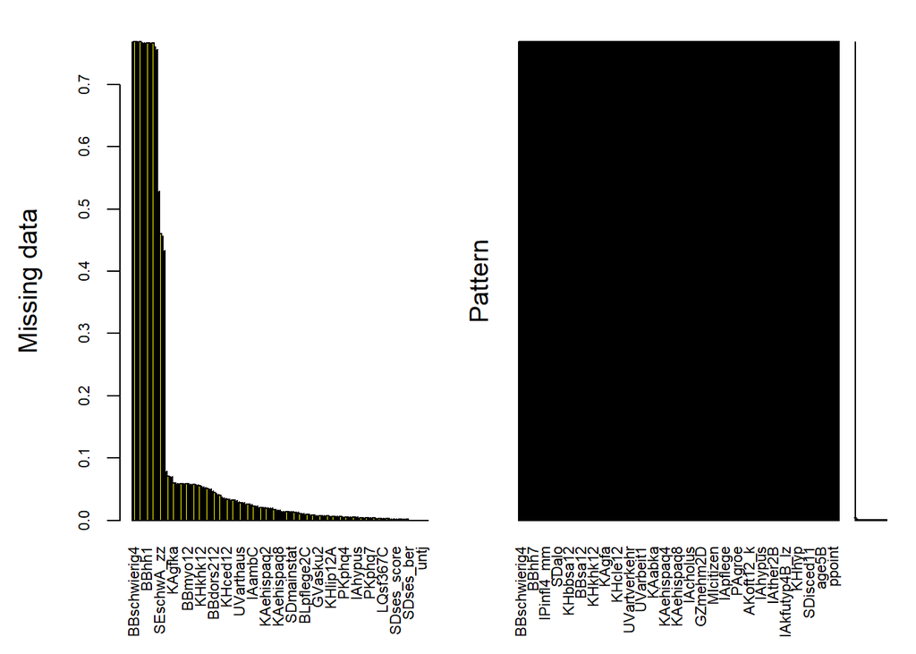

```
##
##  Variables sorted by number of missings:
##            Variable       Count
##        BBschwierig4 0.768904064
##        BBschwierig1 0.768779147
##        BBschwierig2 0.768779147
##        BBschwierig3 0.768779147
##        BBschwierig5 0.768529314
##               BBhh4 0.766988674
##               BBhh7 0.766738841
##               BBhh1 0.766697202
##               BBhh2 0.766613924
##               BBhh3 0.766447368
##               BBhh5 0.766447368
##               BBhh6 0.766280813
##          IPinfl4_mm 0.759826782
##          IPinfl4_jj 0.756245836
##          SEschwA_zz 0.527814790
##       IAkfutyp5B_lz 0.459860093
##       IAkfutyp7B_lz 0.455987675
##           AUarbzD_k 0.433294470
##               SDalo 0.078905730
##              KHra12 0.071160893
##              KHos12 0.069620253
##              KAgfka 0.069203864
##               KAgka 0.060168221
##             KAgka_k 0.060168221
##            KHbbsa12 0.059002332
##   PAhhnbpersk_14_15 0.059002332
##    PAhhnbpersk_5_13 0.058835776
##           KHbbmyo12 0.058794137
##     PAhhnbpersk_0_4 0.058794137
##             BBmyo12 0.058336109
##              BBsa12 0.058336109
##              KHsa12 0.057878081
##              KHhi12 0.057794803
##             KHmyo12 0.057628248
##            KAtbka_k 0.056379081
##              KHab12 0.056004330
##             KHkhk12 0.055921053
```

[output cut: 108 more lines]

```
##           KHhyp12pB 0.002040306
##           KHhypmedC 0.001915390
##             IPinfl4 0.001915390
##           SDses_ber 0.001665556
##                 sex 0.000000000
##               age5B 0.000000000
##         SDaeqeink_k 0.000000000
##          SDses_eink 0.000000000
##         SDhhincomez 0.000000000
##                untm 0.000000000
##                untj 0.000000000
##              ppoint 0.000000000
##               ktyp4 0.000000000
##                bula 0.000000000
##                 wob 0.000000000
```

```r
mice_plot <- aggr(df_base, col=c('navyblue','yellow'),
                    numbers=TRUE, sortVars=TRUE,
                    labels=names(df_base), cex.axis=.7,
                    gap=3, ylab=c("Missing data","Pattern"))
```

Based on the missing values, a low of fields are still containing many NAs due to the fact that they are being asked only to people > 65yrs of age.

```r
df_analysis <- df_base %>% dplyr::select(
  -c(
    BBhh5,
    BBhh6,
    IPinfl4_mm,
    IPinfl4_jj,
    SEschwA_zz,
    IAkfutyp5B_lz,
    IAkfutyp7B_lz,
    AUarbzD_k,

    BBschwierig4,
    BBschwierig1,
    BBschwierig2,
    BBschwierig3,
    BBschwierig5,
    BBhh4,
    BBhh7,
    BBhh1,
    BBhh2,
    BBhh3
  )
)

df_analysis <- na.omit(df_analysis)

df_analysis <-  df_analysis[complete.cases(df_analysis),]

View(df_analysis)


# df_analysis <-  df_analysis %>% naniar::replace_with_na_all(condition = ~.x == 'NA')
```

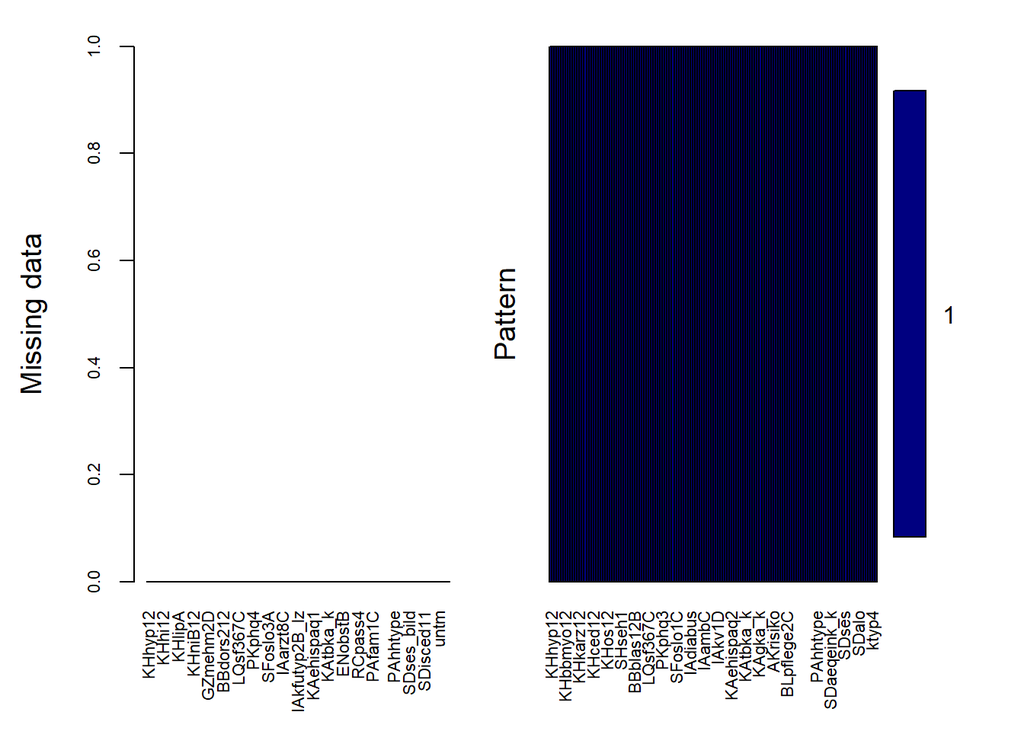

```
##
##  Variables sorted by number of missings:
##            Variable Count
##             KHhyp12     0
##               KHhyp     0
##           KHhyp12pB     0
##           KHhypmedC     0
##             KHmyo12     0
##             KHkhk12     0
##           KHbbmyo12     0
##              KHhi12     0
##              KHsa12     0
##            KHbbsa12     0
##           KHdiabB12     0
##              KHab12     0
##            KHkarz12     0
##            KHlip12A     0
##              KHlipA     0
##           KHlipmedA     0
##              KHcb12     0
##             KHulc12     0
##             KHced12     0
##              KHlz12     0
##             KHcle12     0
##             KHniB12     0
##             KHdge12     0
##              KHra12     0
##              KHos12     0
##           KHalgi112     0
##             GZmehm1     0
##            GZmehm3C     0
##            GZmehm2D     0
##             GZsubj1     0
##              SHseh1     0
##             SHhoer1     0
##             BBmyo12     0
##              BBsa12     0
##           BBdors112     0
##           BBdors212     0
##           BBblas12B     0
```

[output cut: 90 more lines]

```
##               SDses     0
##         SDhhincomez     0
##           SDisced11     0
##            SDhvtypD     0
##            SDerwt0a     0
##          SDmainstat     0
##               SDalo     0
##        MIbirthplace     0
##           MIcitizen     0
##                untm     0
##                untj     0
##              ppoint     0
##               ktyp4     0
##                bula     0
##                 wob     0
```

```r
mice_plot_analysis <- aggr(df_analysis, col=c('navyblue','yellow'),
                    numbers=TRUE, sortVars=TRUE,
                    labels=names(df_analysis), cex.axis=.7,
                    gap=3, ylab=c("Missing data","Pattern"))
```

```r
summary(df_analysis)
```

```
##                        KHhyp12                             KHhyp
##  Nicht erhoben_(-97)       :    0   Nicht erhoben_(-97)       :   0
##  Ja                        : 3448   Ja                        :4268
##  Nein                      :10760   Nein                      :9940
##  Nicht erhoben_(2147483635):    0   Nicht erhoben_(2147483635):   0
##
##
##
##                       KHhyp12pB                          KHhypmedC
##  Nicht erhoben_(-97)       :    0   Nicht erhoben_(-97)       :    0
##  Ja                        : 3539   Ja                        : 3078
##  Nein                      :10669   Nein                      :11130
##  Nicht erhoben_(2147483635):    0   Nicht erhoben_(2147483635):    0
##
##
##
##                        KHmyo12                            KHkhk12
##  Nicht erhoben_(-97)       :    0   Nicht erhoben_(-97)       :    0
##  Ja                        :   78   Ja                        :  329
##  Nein                      :14130   Nein                      :13879
##  Nicht erhoben_(2147483635):    0   Nicht erhoben_(2147483635):    0
##
##
##
##                       KHbbmyo12                            KHhi12
##  Nicht erhoben_(-97)       :    0   Nicht erhoben_(-97)       :    0
##  Ja                        :  136   Ja                        :  366
##  Nein                      :14072   Nein                      :13842
##  Nicht erhoben_(2147483635):    0   Nicht erhoben_(2147483635):    0
##
##
##
##                         KHsa12                            KHbbsa12
##  Nicht erhoben_(-97)       :    0   Nicht erhoben_(-97)       :    0
##  Ja                        :   70   Ja                        :   99
##  Nein                      :14138   Nein                      :14109
##  Nicht erhoben_(2147483635):    0   Nicht erhoben_(2147483635):    0
##
##
##
```

[output cut: 601 more lines]

```
##  Min.   :1410007   Nicht erhoben_(-97)             :   0
##  1st Qu.:1412323   Kreisfreie Großstädte           :4374
##  Median :1415232   Städtische Kreise               :5066
##  Mean   :1414976   Ländliche Kreise                :2225
##  3rd Qu.:1417641   Dünn besiedelte ländliche Kreise:2543
##  Max.   :1419947   Nicht erhoben_(2147483635)      :   0
##
##                   bula                              wob
##  Nordrhein-Westfalen:2327   Nicht erhoben_(-97)       :    0
##  Bayern             :1906   West                      :10564
##  Baden-Württemberg  :1505   Ost                       : 3120
##  Niedersachsen      :1203   Berlin                    :  524
##  Hessen             : 879   Nicht erhoben_(2147483635):    0
##  Sachsen            : 727
##  (Other)            :5661
```

drop unused levels

```r
df_analysis <- df_analysis %>% droplevels

fac <- sapply(df_analysis, levels)

bool_fac <- fac[lapply(fac, length) == 2]

df_analysis$GZmehm1 <- factor(df_analysis$GZmehm1, c("Sehr schlecht",  "Schlecht", "Mittelmäßig","Gut", "Sehr gut"))


summary(df_analysis)
```

```
##  KHhyp12       KHhyp      KHhyp12pB    KHhypmedC    KHmyo12
##  Ja  : 3448   Ja  :4268   Ja  : 3539   Ja  : 3078   Ja  :   78
##  Nein:10760   Nein:9940   Nein:10669   Nein:11130   Nein:14130
##
##
##
##
##
##  KHkhk12      KHbbmyo12     KHhi12       KHsa12      KHbbsa12
##  Ja  :  329   Ja  :  136   Ja  :  366   Ja  :   70   Ja  :   99
##  Nein:13879   Nein:14072   Nein:13842   Nein:14138   Nein:14109
##
##
##
##
##
##  KHdiabB12     KHab12      KHkarz12     KHlip12A      KHlipA
##  Ja  :  726   Ja  :  823   Ja  :  374   Ja  : 2456   Ja  : 3889
##  Nein:13482   Nein:13385   Nein:13834   Nein:11752   Nein:10319
##
##
##
##
##
##  KHlipmedA     KHcb12      KHulc12      KHced12       KHlz12
##  Ja  : 1060   Ja  :  549   Ja  :  120   Ja  :  243   Ja  :   20
##  Nein:13148   Nein:13659   Nein:14088   Nein:13965   Nein:14188
##
##
##
##
##
##  KHcle12      KHniB12      KHdge12       KHra12       KHos12
##  Ja  :  168   Ja  :  191   Ja  : 1805   Ja  :  418   Ja  :  324
##  Nein:14040   Nein:14017   Nein:12403   Nein:13790   Nein:13884
##
##
##
##
##
```

[output cut: 449 more lines]

```
##  Min.   :1410007   Kreisfreie Großstädte           :4374
##  1st Qu.:1412323   Städtische Kreise               :5066
##  Median :1415232   Ländliche Kreise                :2225
##  Mean   :1414976   Dünn besiedelte ländliche Kreise:2543
##  3rd Qu.:1417641
##  Max.   :1419947
##
##                   bula          wob
##  Nordrhein-Westfalen:2327   West  :10564
##  Bayern             :1906   Ost   : 3120
##  Baden-Württemberg  :1505   Berlin:  524
##  Niedersachsen      :1203
##  Hessen             : 879
##  Sachsen            : 727
##  (Other)            :5661
```

## Run a basic ordered logit model

One of the assumptions underlying ordinal logistic (and ordinal probit) regression is that the relationship between each pair of outcome groups is the same. In other words, ordinal logistic regression assumes that the coefficients that describe the relationship between, say, the lowest versus all higher categories of the response variable are the same as those that describe the relationship between the next lowest category and all higher categories, etc. This is called the proportional odds assumption or the parallel regression assumption. Because the relationship between all pairs of groups is the same, there is only one set of coefficients.

Souce: https://stats.idre.ucla.edu/r/dae/ordinal-logistic-regression/

```r
df_test <- df_base %>% dplyr::select(GZmehm1, KHhyp)

# encode factors as numeric

df_test$KHhyp <- as.character(df_test$KHhyp)

df_test[!is.na(df_test$KHhyp) & df_test$KHhyp == 'Ja',]$KHhyp <- '1'
df_test[!is.na(df_test$KHhyp) & df_test$KHhyp == 'Nein',]$KHhyp <- '0'

df_test$KHhyp <- as.numeric(df_test$KHhyp)

df_test <- na.omit(df_test)

m <- polr(GZmehm1 ~ KHhyp, data = df_test, Hess=TRUE)

## view a summary of the model
summary(m)
```

```
## Call:
## polr(formula = GZmehm1 ~ KHhyp, data = df_test, Hess = TRUE)
##
## Coefficients:
##       Value Std. Error t value
## KHhyp 1.388    0.02748    50.5
##
## Intercepts:
##                        Value    Std. Error t value
## Sehr gut|Gut            -1.3034   0.0189   -68.8242
## Gut|Mittelmäßig          1.4436   0.0196    73.6053
## Mittelmäßig|Schlecht     3.6683   0.0343   107.0537
## Schlecht|Sehr schlecht   5.8512   0.0862    67.8952
##
## Residual Deviance: 51522.75
## AIC: 51532.75
```

```r
(ctable <- coef(summary(m)))
```

```
##                            Value Std. Error   t value
## KHhyp                   1.387952 0.02748329  50.50167
## Sehr gut|Gut           -1.303417 0.01893834 -68.82423
## Gut|Mittelmäßig         1.443630 0.01961314  73.60526
## Mittelmäßig|Schlecht    3.668259 0.03426561 107.05365
## Schlecht|Sehr schlecht  5.851154 0.08617914  67.89525
```

```r
p <- pnorm(abs(ctable[, "t value"]), lower.tail = FALSE) * 2
(ctable <- cbind(ctable, "p value" = p))
```

```
##                            Value Std. Error   t value p value
## KHhyp                   1.387952 0.02748329  50.50167       0
## Sehr gut|Gut           -1.303417 0.01893834 -68.82423       0
## Gut|Mittelmäßig         1.443630 0.01961314  73.60526       0
## Mittelmäßig|Schlecht    3.668259 0.03426561 107.05365       0
## Schlecht|Sehr schlecht  5.851154 0.08617914  67.89525       0
```

```r
# (ci <- confint(m))
```

```r
exp(coef(m))
```

```
##    KHhyp
## 4.006636
```

As of now, the interpretation would be: For people that have higher blood pressure, the odds of feeling healthier are 75% lower compared to the people that do not have high BP.

```r
sf <- function(y) {
  c('Y>=1' = qlogis(mean(y >= 1)),
    'Y>=2' = qlogis(mean(y >= 2)),
    'Y>=3' = qlogis(mean(y >= 3)),
    'Y>=4' = qlogis(mean(y >= 4)),
    'Y>=5' = qlogis(mean(y >= 5))
    )
}

(s <- with(df_test, summary(as.numeric(GZmehm1) ~ KHhyp, fun=sf)))
```

```
## as.numeric(GZmehm1)     N= 23850
##
## +-------+---+-----+----+--------+----------+---------+---------+
## |       |   |N    |Y>=1|Y>=2    |Y>=3      |Y>=4     |Y>=5     |
## +-------+---+-----+----+--------+----------+---------+---------+
## |KHhyp  |No |15332|Inf |1.262264|-1.3999657|-3.574574|-5.850634|
## |       |Yes| 8518|Inf |2.976789|-0.0826956|-2.328954|-4.463773|
## +-------+---+-----+----+--------+----------+---------+---------+
## |Overall|   |23850|Inf |1.664794|-0.8550968|-2.960890|-5.124850|
## +-------+---+-----+----+--------+----------+---------+---------+
```

```r
glm(I(as.numeric(GZmehm1) >= 3) ~ KHhyp, family="binomial", data = df_test)
```

```
##
## Call:  glm(formula = I(as.numeric(GZmehm1) >= 3) ~ KHhyp, family = "binomial",
##     data = df_test)
##
## Coefficients:
## (Intercept)        KHhyp
##      -1.400        1.317
##
## Degrees of Freedom: 23849 Total (i.e. Null);  23848 Residual
## Null Deviance:       29070
## Residual Deviance: 27050     AIC: 27050
```

```r
glm(I(as.numeric(GZmehm1) >= 4) ~ KHhyp, family="binomial", data = df_test)
```

```
##
## Call:  glm(formula = I(as.numeric(GZmehm1) >= 4) ~ KHhyp, family = "binomial",
##     data = df_test)
##
## Coefficients:
## (Intercept)        KHhyp
##      -3.575        1.246
##
## Degrees of Freedom: 23849 Total (i.e. Null);  23848 Residual
## Null Deviance:       9360
## Residual Deviance: 8941  AIC: 8945
```

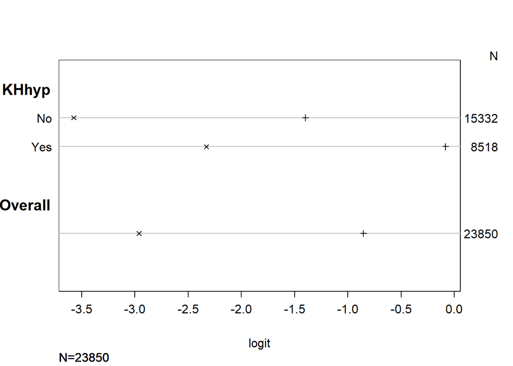

```r
plot(s, which=1:5, pch=1:5, xlab='logit', main=' ', xlim=range(s[,4:5]))
```